# Activity_09

Data for this exercise are taken from the paper “X-ray luminosities of SDSS DR7 clusters from RASS” (Wang+, 2014). The file clusters_xrays.csv contains data for a number of galaxy clusters. Specifically, the columns in the files are:

• LX: absolute luminosity in the X-ray

• Ngal: number of galaxies in the cluster

You want to use these data to estimate the Ngal-Log10(luminosity) relation to be used in future observations to estimate the Number of galaxies from the logarithm of the X-ray luminosity.

Using an MCMC software of your choice, write a Bayesian linear regression model to estimate the unknown regression coeﬀicients.

Plot the estimated posterior distributions of the parameters of the linear model, and summarize your results with your best estimate for the parameters and their 95% credibility intervals.

Plot the data and overplot your best-fit line with the 95% credibility region on the data.

Clusters of galaxies can only be identified if they contain at least 3 galaxies. How do you this this impacts your regression result? Use a MC simulation to justify your conclusion. BONUS: If you have time, using the file GC_allcolumns.txt on canvas, extend the globular cluster analysis we saw in class to simultaneously include: the absolute luminosity M_V [col10] and the “Dynamical mass” of the galaxy [col21]. You may want to consider the Log of the Masses. 1

```python
#Importing packages and reading data

import numpy as np
import pandas as pd
import matplotlib.pyplot as plt
from scipy.stats import poisson
from astropy.io import ascii
from sklearn.linear_model import LinearRegression
import arviz as az
import pymc as pm

df = pd.read_csv("clusters_xrays.csv")
df
galaxies = df['Ngal']
luminosity = np.log10(df['LX'])
```

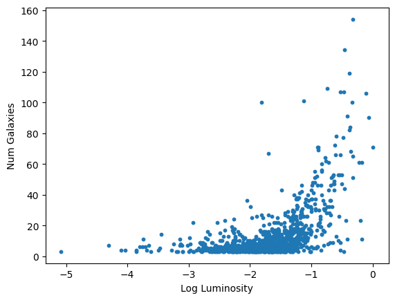

```python
#visualize data

plt.scatter(luminosity, galaxies, s=10)
plt.xlabel('Log Luminosity')
plt.ylabel('Num Galaxies')
```

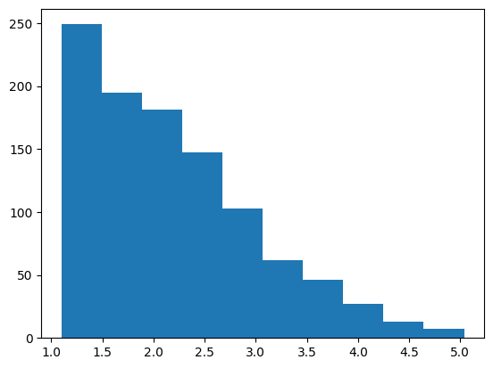

```python
plt.hist(np.log(galaxies))
```

```python
#CutOff at min 10 galaxies per cluster
df10 = df[df['Ngal'] > 9]
new_galaxies = df10['Ngal']
new_luminosity = np.log10(df10['LX'])
```

```python
print(max(galaxies))
```

```
154
```

```python
print(min(galaxies))
```

```
3
```

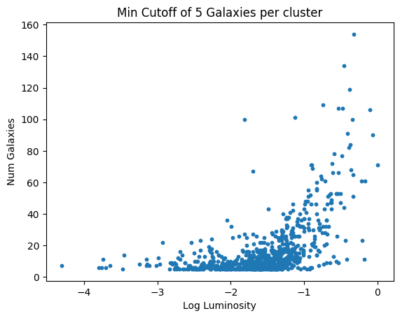

```python
df5 = df[df['Ngal'] > 4]
galaxies_5 = df5['Ngal']
luminosity_5 = np.log10(df5['LX'])

plt.scatter(luminosity_5,galaxies_5, s=10)
plt.xlabel('Log Luminosity')
plt.ylabel('Num Galaxies')
plt.title('Min Cutoff of 5 Galaxies per cluster')
```

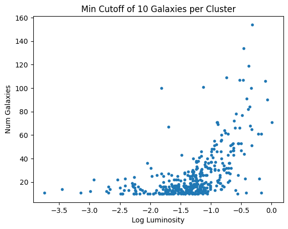

```python
plt.scatter(new_luminosity, new_galaxies, s=10)
plt.xlabel('Log Luminosity')
plt.ylabel('Num Galaxies')
plt.title('Min Cutoff of 10 Galaxies per Cluster')
```

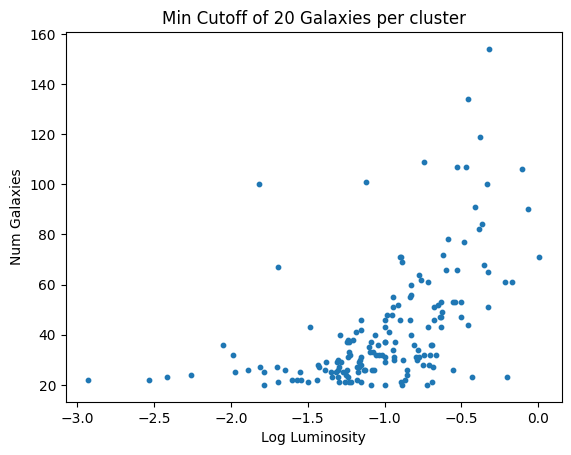

```python
df20 = df[df['Ngal'] > 19]
galaxies_20 = df20['Ngal']
luminosity_20 = np.log10(df20['LX'])

plt.scatter(luminosity_20,galaxies_20, s=10)
plt.xlabel('Log Luminosity')
plt.ylabel('Num Galaxies')
plt.title('Min Cutoff of 20 Galaxies per cluster')
```

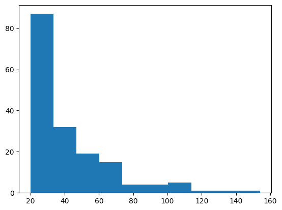

```python
plt.hist(galaxies_20)
```

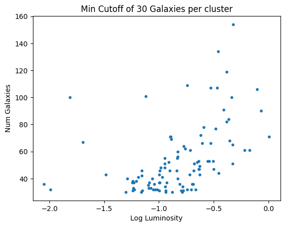

```python
# 30 Galaxies per Cluster
df30 = df[df['Ngal'] > 29]
galaxies_30 = df30['Ngal']
luminosity_30 = np.log10(df30['LX'])

plt.scatter(luminosity_30,galaxies_30, s=10)
plt.xlabel('Log Luminosity')
plt.ylabel('Num Galaxies')
plt.title('Min Cutoff of 30 Galaxies per cluster')
```

Model:

Y = Number of Galaxies ~ Poisson(lambda) Expected value of Y = lambda lambda = e ^ xB

```python
np.std(galaxies)/np.mean(galaxies)
```

```
1.249710445162534
```

```python
#Normal Model

model = pm.Model()
N = len(galaxies)

with model as poisson_log:

    x = pm.MutableData('x',luminosity)
    y = pm.MutableData('y',galaxies)

    # Priors for unknown model parameters
    alpha = pm.Normal('alpha', mu=3, sigma=0.5, initval=1) #Offset so doesn't shoot to infinity
    beta = pm.Normal('beta', mu=0, sigma=0.2, initval=1)

    # Linear model and exponential link
    mu = alpha + beta*x
    mu_y = pm.Deterministic('mu_y',pm.math.exp(mu))
    dispersion = pm.Deterministic('dispersion',pm.math.sum(((y - np.exp(mu))/np.sqrt(np.exp(mu)))**2/(N-2)))

    # Likelihood (sampling distribution) of observations
    Y_obs = pm.Poisson('yobs', mu=pm.math.exp(mu), observed=y)
    trace = pm.sample(draws=10000)
```

```
Auto-assigning NUTS sampler...
Initializing NUTS using jitter+adapt_diag...
Multiprocess sampling (4 chains in 4 jobs)
NUTS: [alpha, beta]
```

100.00% [44000/44000 00:04<00:00 Sampling 4 chains, 0 divergences]

```
Sampling 4 chains for 1_000 tune and 10_000 draw iterations (4_000 + 40_000 draws total) took 5 seconds.
```

```
array([[<Axes: title={'center': 'alpha'}>,
        <Axes: title={'center': 'alpha'}>],
       [<Axes: title={'center': 'beta'}>,
        <Axes: title={'center': 'beta'}>],
       [<Axes: title={'center': 'dispersion'}>,
        <Axes: title={'center': 'dispersion'}>]], dtype=object)
```

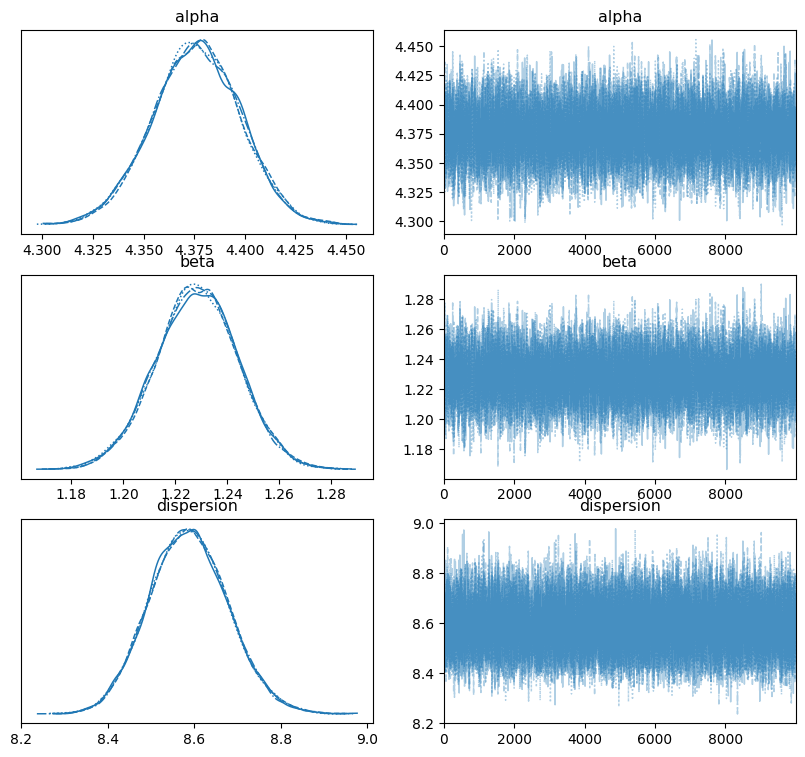

```python
az.plot_trace(trace,var_names=['alpha','beta','dispersion'],figsize=(10, 9))
```

```
array([<Axes: title={'center': 'alpha'}>,
       <Axes: title={'center': 'beta'}>], dtype=object)
```

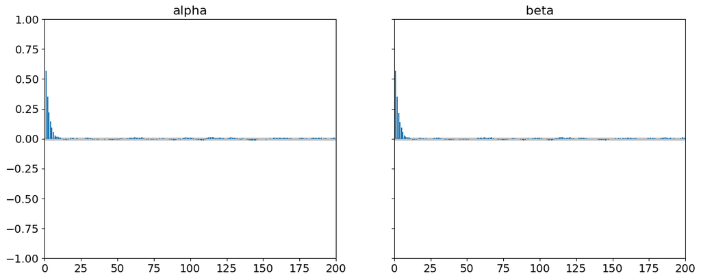

```python
az.plot_autocorr(trace, var_names=['alpha','beta'],combined=True, max_lag=200)
```

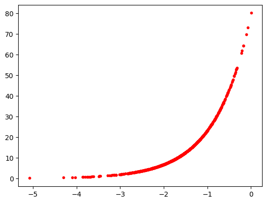

```python
alph = 4.375
bet = 1.23
lambd = alph+bet*luminosity

plt.scatter(luminosity,np.exp(lambd), color = 'red', s=10)
```

# Cutoff of 5 Galaxies

```python
#Try for different cutoff values - Min 10

model5 = pm.Model()
N = len(galaxies_5)

with model5 as poisson_log:

    x = pm.MutableData('x',luminosity_5)
    y = pm.MutableData('y',galaxies_5)

    # Priors for unknown model parameters
    alpha = pm.Normal('alpha', mu=3, sigma=0.5, initval=1) #Offset so doesn't shoot to infinity
    beta = pm.Normal('beta', mu=0, sigma=0.2, initval=1)

    # Linear model and exponential link
    mu = alpha + beta*x
    mu_y = pm.Deterministic('mu_y',pm.math.exp(mu))
    dispersion = pm.Deterministic('dispersion',pm.math.sum(((y - np.exp(mu))/np.sqrt(np.exp(mu)))**2/(N-2)))

    # Likelihood (sampling distribution) of observations
    Y_obs = pm.Poisson('yobs', mu=pm.math.exp(mu), observed=y)
    trace = pm.sample(draws=10000)
```

```
Auto-assigning NUTS sampler...
Initializing NUTS using jitter+adapt_diag...
Multiprocess sampling (4 chains in 4 jobs)
NUTS: [alpha, beta]
```

100.00% [44000/44000 00:04<00:00 Sampling 4 chains, 0 divergences]

```
Sampling 4 chains for 1_000 tune and 10_000 draw iterations (4_000 + 40_000 draws total) took 4 seconds.
```

```
array([[<Axes: title={'center': 'alpha'}>,
        <Axes: title={'center': 'alpha'}>],
       [<Axes: title={'center': 'beta'}>,
        <Axes: title={'center': 'beta'}>],
       [<Axes: title={'center': 'dispersion'}>,
        <Axes: title={'center': 'dispersion'}>]], dtype=object)
```

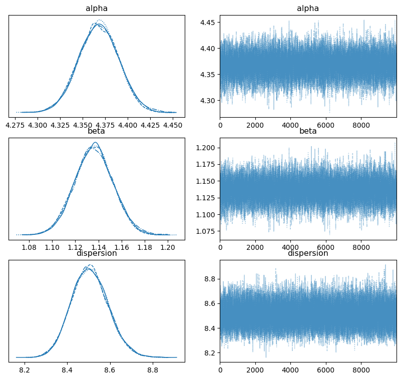

```python
az.plot_trace(trace,var_names=['alpha','beta','dispersion'],figsize=(10, 9))
```

# Cutoff of 10 Galaxies

```python
#Try for different cutoff values - Min 10

model2 = pm.Model()
N = len(new_galaxies)

with model2 as poisson_log:

    x = pm.MutableData('x',new_luminosity)
    y = pm.MutableData('y',new_galaxies)

    # Priors for unknown model parameters
    alpha = pm.Normal('alpha', mu=3, sigma=0.5, initval=1) #Offset so doesn't shoot to infinity
    beta = pm.Normal('beta', mu=0, sigma=0.2, initval=1)

    # Linear model and exponential link
    mu = alpha + beta*x
    mu_y = pm.Deterministic('mu_y',pm.math.exp(mu))
    dispersion = pm.Deterministic('dispersion',pm.math.sum(((y - np.exp(mu))/np.sqrt(np.exp(mu)))**2/(N-2)))

    # Likelihood (sampling distribution) of observations
    Y_obs = pm.Poisson('yobs', mu=pm.math.exp(mu), observed=y)
    trace = pm.sample(draws=10000)
```

```
Auto-assigning NUTS sampler...
Initializing NUTS using jitter+adapt_diag...
Multiprocess sampling (4 chains in 4 jobs)
NUTS: [alpha, beta]
```

100.00% [44000/44000 00:03<00:00 Sampling 4 chains, 0 divergences]

```
Sampling 4 chains for 1_000 tune and 10_000 draw iterations (4_000 + 40_000 draws total) took 4 seconds.
```

```
array([[<Axes: title={'center': 'alpha'}>,
        <Axes: title={'center': 'alpha'}>],
       [<Axes: title={'center': 'beta'}>,
        <Axes: title={'center': 'beta'}>],
       [<Axes: title={'center': 'dispersion'}>,
        <Axes: title={'center': 'dispersion'}>]], dtype=object)
```

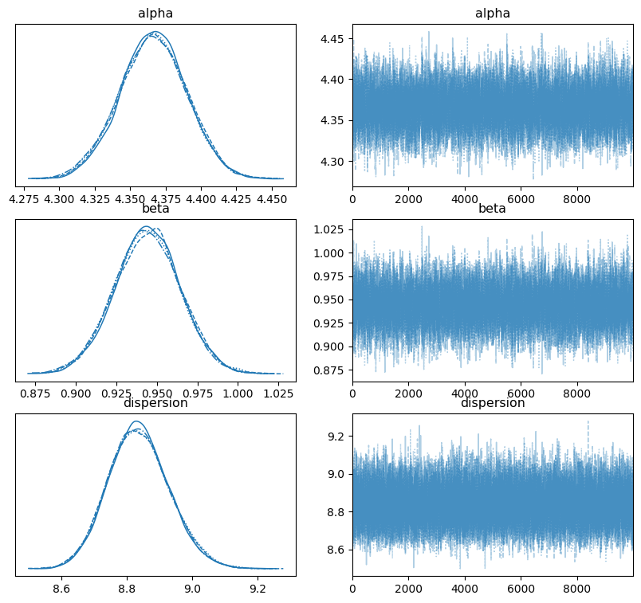

```python
az.plot_trace(trace,var_names=['alpha','beta','dispersion'],figsize=(10, 9))
```

# Cutoff of 20 Galaxies

```python
#Try for different cutoff values - 20

model3 = pm.Model()

N = len(galaxies_20)

with model3 as poisson_log:

    x = pm.MutableData('x',luminosity_20)
    y = pm.MutableData('y',galaxies_20)

    # Priors for unknown model parameters
    alpha = pm.Normal('alpha', mu=3, sigma=0.5, initval=1) #Offset so doesn't shoot to infinity
    beta = pm.Normal('beta', mu=0, sigma=0.2, initval=1)

    # Linear model and exponential link
    mu = alpha + beta*x
    mu_y = pm.Deterministic('mu_y',pm.math.exp(mu))
    dispersion = pm.Deterministic('dispersion',pm.math.sum(((y - np.exp(mu))/np.sqrt(np.exp(mu)))**2/(N-2)))

    # Likelihood (sampling distribution) of observations
    Y_obs = pm.Poisson('yobs', mu=pm.math.exp(mu), observed=y)
    trace = pm.sample(draws=10000)
```

```
Auto-assigning NUTS sampler...
Initializing NUTS using jitter+adapt_diag...
Multiprocess sampling (4 chains in 4 jobs)
NUTS: [alpha, beta]
```

100.00% [44000/44000 00:02<00:00 Sampling 4 chains, 0 divergences]

```
Sampling 4 chains for 1_000 tune and 10_000 draw iterations (4_000 + 40_000 draws total) took 3 seconds.
```

```
array([[<Axes: title={'center': 'alpha'}>,
        <Axes: title={'center': 'alpha'}>],
       [<Axes: title={'center': 'beta'}>,
        <Axes: title={'center': 'beta'}>],
       [<Axes: title={'center': 'dispersion'}>,
        <Axes: title={'center': 'dispersion'}>]], dtype=object)
```

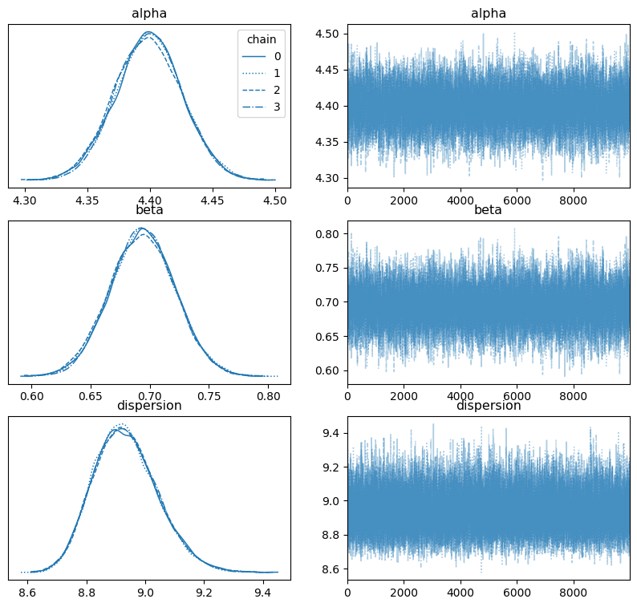

```python
az.plot_trace(trace,var_names=['alpha','beta','dispersion'],figsize=(10, 9), legend=True)
```

# Cutoff of 30 Galaxies

```python
#Try for different cutoff values - 20

model4 = pm.Model()

N = len(galaxies_30)

with model4 as poisson_log:

    x = pm.MutableData('x',luminosity_30)
    y = pm.MutableData('y',galaxies_30)

    # Priors for unknown model parameters
    alpha = pm.Normal('alpha', mu=3, sigma=0.5, initval=1) #Offset so doesn't shoot to infinity
    beta = pm.Normal('beta', mu=0, sigma=0.2, initval=1)

    # Linear model and exponential link
    mu = alpha + beta*x
    mu_y = pm.Deterministic('mu_y',pm.math.exp(mu))
    dispersion = pm.Deterministic('dispersion',pm.math.sum(((y - np.exp(mu))/np.sqrt(np.exp(mu)))**2/(N-2)))

    # Likelihood (sampling distribution) of observations
    Y_obs = pm.Poisson('yobs', mu=pm.math.exp(mu), observed=y)
    trace = pm.sample(draws=10000)
```

```
Auto-assigning NUTS sampler...
Initializing NUTS using jitter+adapt_diag...
Multiprocess sampling (4 chains in 4 jobs)
NUTS: [alpha, beta]
```

100.00% [44000/44000 00:02<00:00 Sampling 4 chains, 0 divergences]

```
Sampling 4 chains for 1_000 tune and 10_000 draw iterations (4_000 + 40_000 draws total) took 3 seconds.
```

```
array([[<Axes: title={'center': 'alpha'}>,
        <Axes: title={'center': 'alpha'}>],
       [<Axes: title={'center': 'beta'}>,
        <Axes: title={'center': 'beta'}>],
       [<Axes: title={'center': 'dispersion'}>,
        <Axes: title={'center': 'dispersion'}>]], dtype=object)
```

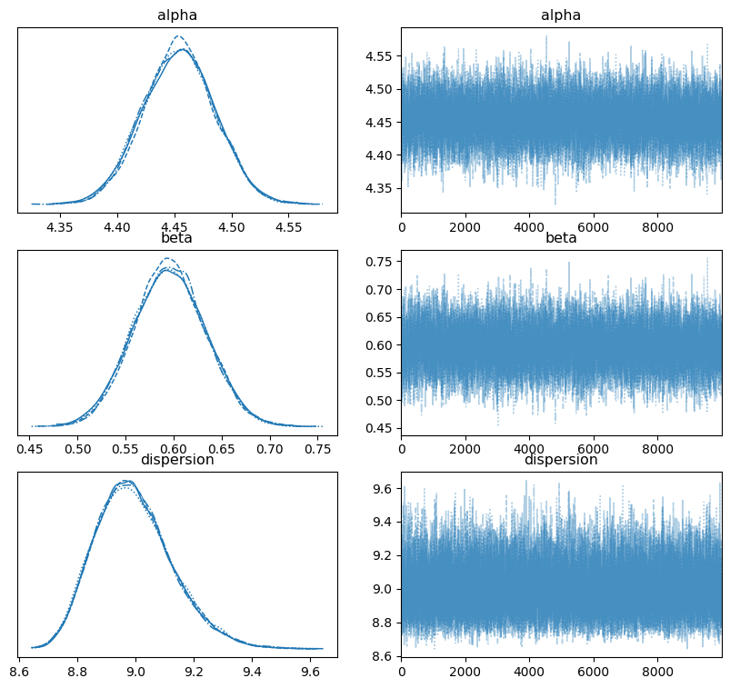

```python
az.plot_trace(trace,var_names=['alpha','beta','dispersion'],figsize=(10, 9))
```

[figure not shown]

```python
az.plot_posterior(trace.posterior[["beta","alpha","dispersion"]],figsize=(13, 6), hdi_prob=0.95)
beta_lb = .52
beta_ub = 0.67
alpha_lb= 4.4
alpha_ub = 4.5
```

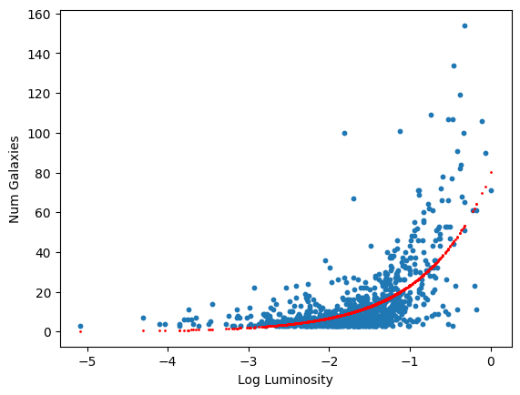

```python
plt.scatter(luminosity, galaxies, s=10)
plt.xlabel('Log Luminosity')
plt.ylabel('Num Galaxies')
plt.scatter(luminosity,np.exp(lambd), color = 'red',s=1)
```

```python
lambd_lb = alpha_lb+beta_lb*luminosity
lambd_ub = alpha_ub+beta_ub*luminosity
```

```python
dat = pd.DataFrame[[luminosity],[np.exp(lambd)]]
```

[output not shown]